# Time Series: A First Course with Bootstrap Starter

# Lesson 4-5: Time Series Prediction

- We apply projection techniques to predict (or forecast) time series.

## Paradigm 4.5.1. The Conditional Expectation

- Let $\{ X_t \}$ be a weakly stationary time series in ${\mathbb L}_2$.
- Suppose for some $t > n$ we wish to predict $X_t$ from $X_1, \ldots, X_n$. The predictor is denoted $\widehat{X}_t$.
- We want the prediction error to have minimal mean square:
  $${\mathbb E} [ {( \widehat{X}_t - X_t)}^2]$$
  is the Mean Squared Error (MSE).
- Theorem 4.5.2. The minimal MSE predictor is the conditional expectation:
  $$\widehat{X}_t = {\mathbb E} [ X_t \vert X_1, \ldots, X_n].$$

## Example 4.5.6. Order One Autoregression

- Let $\{ X_t \}$ be an AR(1), i.e., $X_t = \phi X_{t-1} + Z_t$ with $\{ Z_t \}$ i.i.d. $(0,\sigma^2)$.
- Assume $Z_t$ is independent of $X_s$ for all $s < t$.

### One-step ahead prediction

- Consider predicting one-step ahead: we want $\widehat{X}_{n+1}$, given $X_1, \ldots, X_n$.
- We calculate the conditional expectation:
  $$\begin{align*}
  {\mathbf E} [ X_{n+1} \vert X_1, \ldots, X_n] & =
  {\mathbf E} [ \phi X_n + Z_{n+1} \vert X_1, \ldots, X_n] \\
  & = \phi \, {\mathbf E} [ X_{n} \vert X_1, \ldots, X_n]
  + {\mathbf E} [ Z_{n+1} \vert X_1, \ldots, X_n] \\
  & = \phi \, X_n + 0.
  \end{align*}$$
  This uses linearity of conditional expectation, and independence of $Z_{n+1}$ from $X_1, \ldots, X_n$.
- The prediction error is then
  $$X_{n+1} - \widehat{X}_{n+1} = X_{n+1} - \phi \, X_n = Z_{n+1},$$
  so that the MSE is ${\mathbb E} [ Z_{n+1}^2] = \sigma^2$.

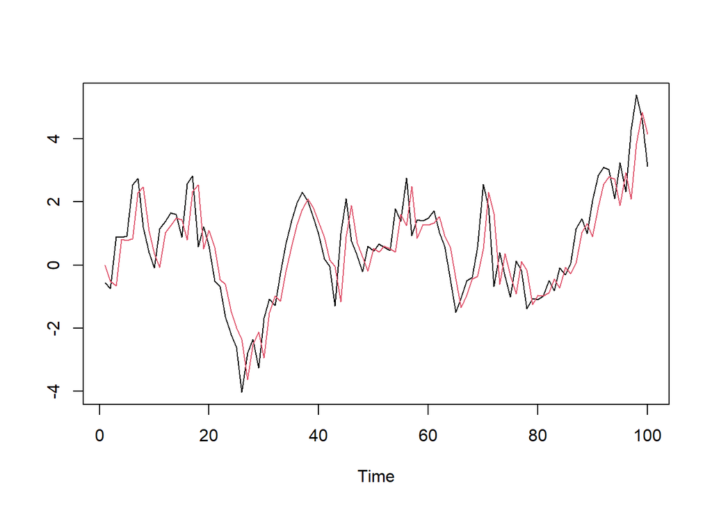

```r
set.seed(123)
n <- 100
z <- rnorm(n)
x <- rep(0,n)
xhat <- rep(0,n)
phi <- .9
x0 <- 0
x[1] <- x0 + z[1]
for(t in 2:n)
{
  x[t] <- phi*x[t-1] + z[t]
  xhat[t] <- phi*x[t-1]
}
plot(ts(x),xlab="Time",ylab="")
lines(ts(xhat),col=2)
```

### Two-step ahead prediction

- Consider predicting two steps ahead: we want $\widehat{X}_{n+2}$, given $X_1, \ldots, X_n$.
- Note that by applying the AR(1) recursion twice we can write
  $$X_{n+2} = \phi^2 X_n + \phi Z_{n+1} + Z_{n+2}.$$
- Hence the conditional expectation is
  $$\begin{align*}
  {\mathbf E} [ X_{n+2} \vert X_1, \ldots, X_n] & =
  {\mathbf E} [ \phi^2 X_n + \phi Z_{n+1} + Z_{n+2} \vert X_1, \ldots,
  X_n] \\
  & = \phi^2 \, {\mathbf E} [ X_{n} \vert X_1, \ldots, X_n]
  + \phi \, {\mathbf E} [ Z_{n+1} \vert X_1, \ldots, X_n]
  + {\mathbf E} [ Z_{n+2} \vert X_1, \ldots, X_n] \\
  & = \phi^2 \, X_n + 0.
  \end{align*}$$
- The prediction error is
  $$X_{n+2} - \widehat{X}_{n+2} = \phi^2 X_n + \phi Z_{n+1} + Z_{n+2}
  - \phi^2 X_n = \phi Z_{n+1} + Z_{n+2}.$$
  Hence the prediction MSE is $(1 + \phi^2) \sigma^2$.

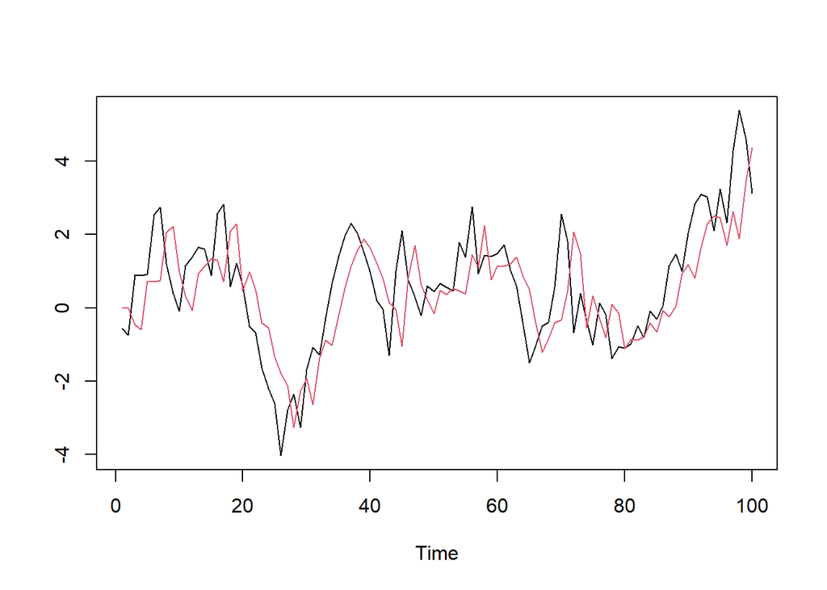

```r
set.seed(123)
n <- 100
z <- rnorm(n)
x <- rep(0,n)
xhat <- rep(0,n)
phi <- .9
x0 <- 0
x[1] <- x0 + z[1]
x[2] <- phi*x[1] + z[2]
for(t in 3:n)
{
  x[t] <- phi*x[t-1] + z[t]
  xhat[t] <- phi^2*x[t-2]
}
plot(ts(x),xlab="Time",ylab="")
lines(ts(xhat),col=2)
```